Introduction.

Data background and data source: Using devices such as Jawbone Up, Nike FuelBand, and Fitbit it is now possible to collect a large amount of data about personal activity relatively inexpensively. These type of devices are part of the quantified self movement – a group of enthusiasts who take measurements about themselves regularly to improve their health, to find patterns in their behavior, or because they are tech geeks. One thing that people regularly do is quantify how much of a particular activity they do, but they rarely quantify how well they do it.

The data for this project come from this source: http://groupware.les.inf.puc-rio.br/har.

The training data for this project are available here:

https://d396qusza40orc.cloudfront.net/predmachlearn/pml-training.csv

The test data are available here:

https://d396qusza40orc.cloudfront.net/predmachlearn/pml-testing.csv

In this project, the goal is to use data from accelerometers on the belt, forearm, arm, and dumbell of 6 participants. They were asked to perform barbell lifts correctly and incorrectly in 5 different ways. More information is available from the website here: http://groupware.les.inf.puc-rio.br/har (see the section on the Weight Lifting Exercise Dataset).

# Brief description of the analysis performed step by step.

We start with loading the necessary libraries:

```r
set.seed(1984)
library(caret)
```

```r
library(rpart)
library(lattice)
library(ggplot2)
library(rattle)
library(randomForest)
```

# Step 1: Load the data and perform initial exploratory analysis

```r
setwd("~/Documents/COURSEWORK/Coursera/Practical_ML/Project")
training =  read.csv(file = "pml-training.csv", header = TRUE, na.strings=c("NA","#DIV/0!",""))
testing =  read.csv(file = "pml-testing.csv", header = TRUE, na.strings=c("NA","#DIV/0!",""))

str(training)
```

```
## 'data.frame':    19622 obs. of  160 variables:
##  $ X                       : int  1 2 3 4 5 6 7 8 9 10 ...
##  $ user_name               : Factor w/ 6 levels "adelmo","carlitos",..: 2 2 2 2 2 2 2 2 2 2 ...
##  $ raw_timestamp_part_1    : int  1323084231 1323084231 1323084231 1323084232 1323084232 1323084232 1323084232 1323084232 1323084232 1323084232 ...
##  $ raw_timestamp_part_2    : int  788290 808298 820366 120339 196328 304277 368296 440390 484323 484434 ...
##  $ cvtd_timestamp          : Factor w/ 20 levels "02/12/2011 13:32",..: 9 9 9 9 9 9 9 9 9 9 ...
##  $ new_window              : Factor w/ 2 levels "no","yes": 1 1 1 1 1 1 1 1 1 1 ...
##  $ num_window              : int  11 11 11 12 12 12 12 12 12 12 ...
##  $ roll_belt               : num  1.41 1.41 1.42 1.48 1.48 1.45 1.42 1.42 1.43 1.45 ...
##  $ pitch_belt              : num  8.07 8.07 8.07 8.05 8.07 8.06 8.09 8.13 8.16 8.17 ...
##  $ yaw_belt                : num  -94.4 -94.4 -94.4 -94.4 -94.4 -94.4 -94.4 -94.4 -94.4 -94.4 ...
##  $ total_accel_belt        : int  3 3 3 3 3 3 3 3 3 3 ...
##  $ kurtosis_roll_belt      : num  NA NA NA NA NA NA NA NA NA NA ...
##  $ kurtosis_picth_belt     : num  NA NA NA NA NA NA NA NA NA NA ...
##  $ kurtosis_yaw_belt       : logi  NA NA NA NA NA NA ...
```

[output cut: 86 more lines]

```r
summary(training$classe)
```

```
##    A    B    C    D    E
## 5580 3797 3422 3216 3607
```

```r
summary(training$user_name)
```

```
##   adelmo carlitos  charles   eurico   jeremy    pedro
##     3892     3112     3536     3070     3402     2610
```

```r
summary(training$cvtd_timestamp)
```

```
## 02/12/2011 13:32 02/12/2011 13:33 02/12/2011 13:34 02/12/2011 13:35
##              177             1321             1375             1019
## 02/12/2011 14:56 02/12/2011 14:57 02/12/2011 14:58 02/12/2011 14:59
##              235             1380             1364              557
## 05/12/2011 11:23 05/12/2011 11:24 05/12/2011 11:25 05/12/2011 14:22
##              190             1497             1425              267
## 05/12/2011 14:23 05/12/2011 14:24 28/11/2011 14:13 28/11/2011 14:14
##             1370              973              833             1498
## 28/11/2011 14:15 30/11/2011 17:10 30/11/2011 17:11 30/11/2011 17:12
##              739              869             1440             1093
```

I have omitted the report on each and every variable for the purpose of keeping the write up leaner.

# Step 2: Partition the data

```r
inTrain = createDataPartition(y = training$classe, p = 0.6, list = FALSE)
training1 = training[inTrain, ]
testing1 = training[ -inTrain, ]
```

This created a data partiotion with 60% data for training and 40% set aside for testing.

# Step 3: Cleaning the data

First, we will identify variables with near zero variance and exclude them from the dataset.

```r
NZV = nearZeroVar(training1, freqCut = 90/10, uniqueCut = 20, saveMetrics=TRUE)
NZV_varaibles = names(training1) %in% c(rownames(NZV[NZV$nzv ==TRUE,]))
training1_NZV = training1[!NZV_varaibles]
dim(training1_NZV)
```

```
## [1] 11776   120
```

Identify and put aside variables with more than 90% NAs.

```r
na_thrhold = 0.9 # threshold for % of NA'S
counter = numeric()
for (i in 1:dim(training1_NZV)[2]){
  if ( sum( is.na(training1_NZV[,i]) )/dim(training1_NZV)[1] >= na_thrhold )
    counter = c(counter, i)
}

training1_NZV_NA = training1_NZV[,-counter]
dim(training1_NZV_NA)
```

```
## [1] 11776    56
```

This leaves us with 54 variables excluding the index variable and response classe.

Cleaning the testing dataset using the same criteria:

```r
testing1_NZV_NA = testing1[colnames(training1_NZV_NA)]
```

# Step 4: Fit Decision Tree model (DT)

```r
modFit_DT = rpart(classe ~ ., data = training1_NZV_NA[,-1], method = "class")
```

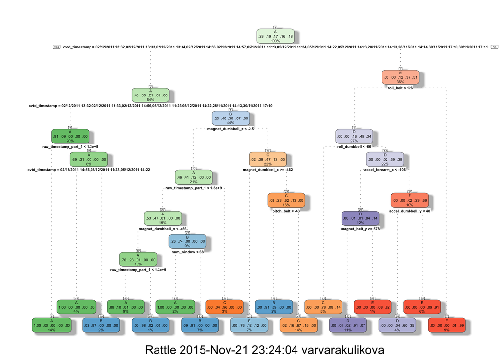

```r
predict_DT = predict(modFit_DT, testing1_NZV_NA[,-1], type = "class")

confusionMatrix(predict_DT, testing1_NZV_NA$classe)
```

```
## Confusion Matrix and Statistics
##
##           Reference
## Prediction    A    B    C    D    E
##          A 2156   52    6    3    0
##          B   59 1260   75   62    0
##          C   17  193 1266  203   54
##          D    0   13   19  940  168
##          E    0    0    2   78 1220
##
## Overall Statistics
##
##                Accuracy : 0.872
##                  95% CI : (0.8644, 0.8794)
##     No Information Rate : 0.2845
##     P-Value [Acc > NIR] : < 2.2e-16
##
##                   Kappa : 0.8382
##  Mcnemar's Test P-Value : NA
##
## Statistics by Class:
##
##                      Class: A Class: B Class: C Class: D Class: E
## Sensitivity            0.9659   0.8300   0.9254   0.7309   0.8460
## Specificity            0.9891   0.9690   0.9279   0.9695   0.9875
## Pos Pred Value         0.9725   0.8654   0.7305   0.8246   0.9385
## Neg Pred Value         0.9865   0.9596   0.9833   0.9484   0.9661
## Prevalence             0.2845   0.1935   0.1744   0.1639   0.1838
## Detection Rate         0.2748   0.1606   0.1614   0.1198   0.1555
## Detection Prevalence   0.2826   0.1856   0.2209   0.1453   0.1657
## Balanced Accuracy      0.9775   0.8995   0.9267   0.8502   0.9168
```

Predict on the original testing set using DT:

```r
testing_NZV_NA = testing[,names(testing) %in% names(training1_NZV_NA)]
predict_DT_test = predict(modFit_DT, testing_NZV_NA[,-1], type = "class")
predict_DT_test
```

```
##  1  2  3  4  5  6  7  8  9 10 11 12 13 14 15 16 17 18 19 20
##  B  A  C  A  A  E  D  C  A  A  B  C  B  A  E  E  A  B  B  B
## Levels: A B C D E
```

```r
## In sample error
predict_DT_train = predict(modFit_DT, training1_NZV_NA[,-1], type = "class")
confusionMatrix(predict_DT_train, training1_NZV_NA$classe)[3]
```

```
## $overall
##       Accuracy          Kappa  AccuracyLower  AccuracyUpper   AccuracyNull
##      0.8735564      0.8401197      0.8674188      0.8795086      0.2843071
## AccuracyPValue  McnemarPValue
##      0.0000000            NaN
```

Fit Random Forest (RF)

```r
modFit_RF = randomForest(classe ~ ., data = training1_NZV_NA[,-1] )
```

```r
predict_RF = predict(modFit_RF, testing1_NZV_NA[,-1], type = "class")
confusionMatrix(predict_RF, testing1_NZV_NA$classe)
```

```
## Confusion Matrix and Statistics
##
##           Reference
## Prediction    A    B    C    D    E
##          A 2230    3    0    0    0
##          B    2 1512    1    0    0
##          C    0    3 1367    0    0
##          D    0    0    0 1286    3
##          E    0    0    0    0 1439
##
## Overall Statistics
##
##                Accuracy : 0.9985
##                  95% CI : (0.9973, 0.9992)
##     No Information Rate : 0.2845
##     P-Value [Acc > NIR] : < 2.2e-16
##
##                   Kappa : 0.9981
##  Mcnemar's Test P-Value : NA
##
## Statistics by Class:
##
##                      Class: A Class: B Class: C Class: D Class: E
## Sensitivity            0.9991   0.9960   0.9993   1.0000   0.9979
## Specificity            0.9995   0.9995   0.9995   0.9995   1.0000
## Pos Pred Value         0.9987   0.9980   0.9978   0.9977   1.0000
## Neg Pred Value         0.9996   0.9991   0.9998   1.0000   0.9995
## Prevalence             0.2845   0.1935   0.1744   0.1639   0.1838
## Detection Rate         0.2842   0.1927   0.1742   0.1639   0.1834
## Detection Prevalence   0.2846   0.1931   0.1746   0.1643   0.1834
## Balanced Accuracy      0.9993   0.9978   0.9994   0.9998   0.9990
```

```r
predict_RF_train = predict(modFit_RF, training1_NZV_NA[,-1], type = "class")
confusionMatrix(predict_RF_train, training1_NZV_NA$classe)
```

```
## Confusion Matrix and Statistics
##
##           Reference
## Prediction    A    B    C    D    E
##          A 3348    0    0    0    0
##          B    0 2279    0    0    0
##          C    0    0 2054    0    0
##          D    0    0    0 1930    0
##          E    0    0    0    0 2165
##
## Overall Statistics
##
##                Accuracy : 1
##                  95% CI : (0.9997, 1)
##     No Information Rate : 0.2843
##     P-Value [Acc > NIR] : < 2.2e-16
##
##                   Kappa : 1
##  Mcnemar's Test P-Value : NA
##
## Statistics by Class:
##
##                      Class: A Class: B Class: C Class: D Class: E
## Sensitivity            1.0000   1.0000   1.0000   1.0000   1.0000
## Specificity            1.0000   1.0000   1.0000   1.0000   1.0000
## Pos Pred Value         1.0000   1.0000   1.0000   1.0000   1.0000
## Neg Pred Value         1.0000   1.0000   1.0000   1.0000   1.0000
## Prevalence             0.2843   0.1935   0.1744   0.1639   0.1838
## Detection Rate         0.2843   0.1935   0.1744   0.1639   0.1838
## Detection Prevalence   0.2843   0.1935   0.1744   0.1639   0.1838
## Balanced Accuracy      1.0000   1.0000   1.0000   1.0000   1.0000
```

Accuracy is 100% of an in sample data, with the in sample error of 0%.

Final Step:

Predict on the original testing set using RF. To make sure that RandomForest prediction works with the Test data set coerce the data into the same type.

```r
for (i in 1:length(testing_NZV_NA) ) {
  for(j in 1:length(training1_NZV_NA)) {
    if( length( grep(names(training1_NZV_NA[i]), names(testing_NZV_NA)[j]) ) ==1)  {
      class(testing_NZV_NA[j]) <- class(training1_NZV_NA[i])
    }
  }
}

## corce two data frames, i suspect it passes all the variable types and levels for factors, so they match for bpth data frames
anyrow = 50
testing_NZV_NA = rbind(training1_NZV_NA[anyrow, -56] , testing_NZV_NA)
testing_NZV_NA = testing_NZV_NA[-1,]

predict_RF_test = predict(modFit_RF, testing_NZV_NA[,-1], type = "class")
```

The final predictions are:

1 2 3 4 5 6 7 8 9 10 11 12 13 14 15 16 17 18 19 20

B A C A A E D C A A B C B A E E A B B B

For submission purposes, the following function had been utilized to write predictions into separate files:

```r
pml_write_files = function(x){
  n = length(x)
  for(i in 1:n){
    filename = paste0("problem_id_",i,".txt")
    write.table(x[i],file=filename,quote=FALSE,row.names=FALSE,col.names=FALSE)
  }
}

pml_write_files(predict_RF_test)
```